title: “weatherAUS - rain tommorow prediction”

author: “Mikołaj Malec”

date: “4/6/2020”

output: html_document

## Loading data

This dataset has daily weather observations from many Australian weather stations.

The target variable RainTomorrow means: Did it rain the next day?

```r
library( rattle.data)

dirty_df <- rattle.data::weatherAUS

orginal_dim <- dim(dirty_df)
```

## Cutting data

There is no need for rows with missing target and columns with already predicted rain risk.

Also columns with many missing data aren’t helpful.

Wind direction may be important, but they have very little correlation with target and others categories. To simplify the model wind direction were removed.

There are to many locations, they were mean encoded at this stage.

Year and day aren’t that important and could lead to overfitting. Date was reduced to months. In the left data there are 0.79 full rows. There is no need to fill missing vales because remaing data is still huge.

In the end 8 columns were deleted and 77% of originals rows from loaded data remained.

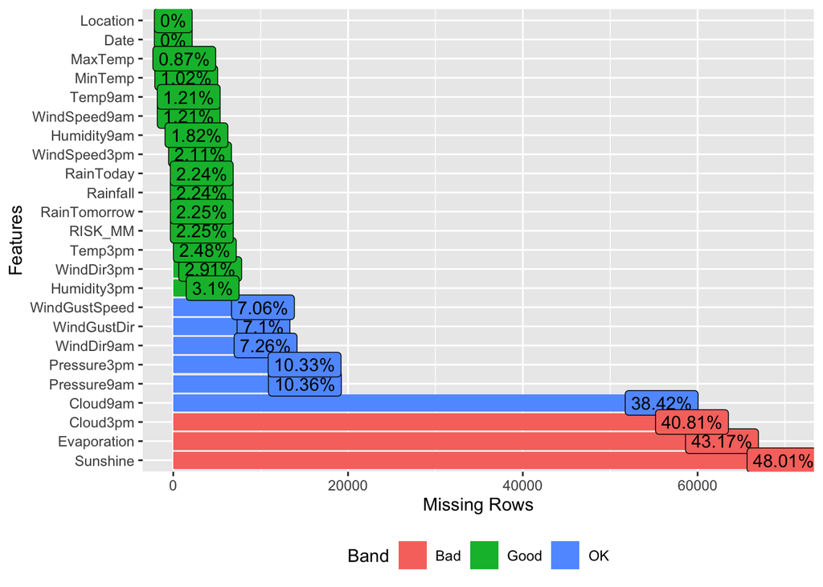

```r
#exploration

library( DataExplorer)

#DataExplorer::create_report(dirty_df)



DataExplorer::plot_missing( dirty_df)
```

```r
#rows with missing target

dirty_df<- dirty_df[ complete.cases( dirty_df$RainTomorrow),]

#column with risk of rain tomorrow

dirty_df$RISK_MM <- NULL



#cut columns with more than 37% missing values:

#Cloud9am, Cloud3pm, Evaporation, Sunshine

dirty_df[,which( colnames(dirty_df) %in% c("Cloud9am", "Cloud3pm", "Evaporation", "Sunshine"))] <- NULL







info <- DataExplorer::introduce(dirty_df)

info$complete_rows / info$rows
```

```
## [1] 0.7941671
```

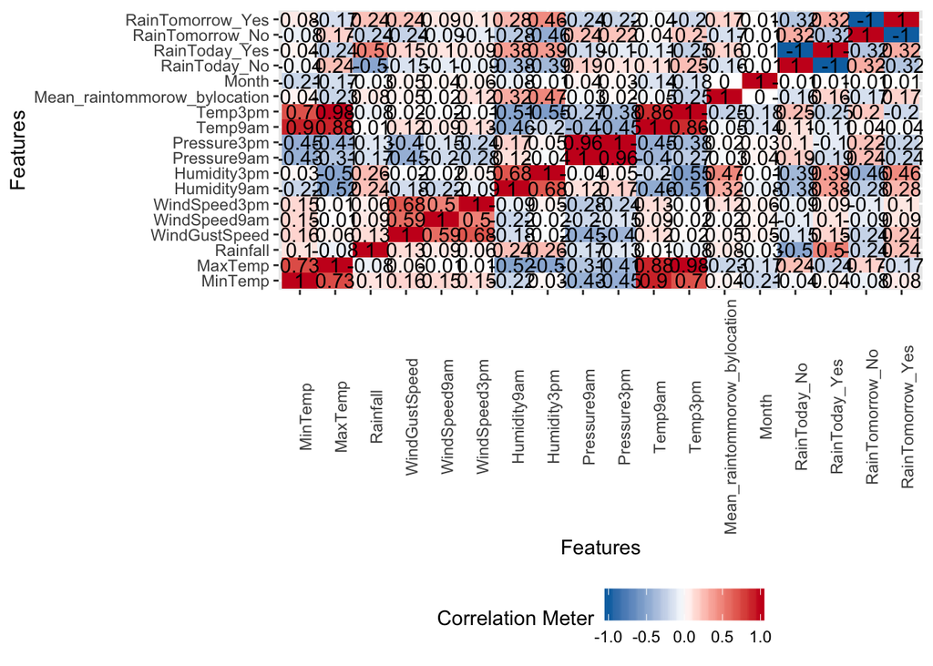

```r
#only rows with no missing value

dirty_df <- dirty_df[ complete.cases(dirty_df),]



#WindGustDir, WindDir9am, WindDir3pm very little correlation with target

dirty_df[,which( colnames(dirty_df) %in% c("WindGustDir", "WindDir9am", "WindDir3pm"))] <- NULL



#Location

dirty_df$Mean_raintommorow_bylocation <- ave( as.numeric( dirty_df$RainTomorrow) - 1, dirty_df$Location)

dirty_df$Location <- NULL



#Date

months <- as.character( dirty_df$Date) %>% substr(6,7)

dirty_df$Month <- as.numeric( months)

dirty_df$Date <- NULL





DataExplorer::plot_correlation( dirty_df)
```

```r
#summary of df_dirty

data.frame(list(orginal = orginal_dim),

                final = dim(dirty_df),

                diff = orginal_dim - dim(dirty_df),

                proc = dim(dirty_df) / orginal_dim,

           row.names = c("Rows", "Columns"))
```

```
##         orginal  final  diff      proc
## Rows     145460 112925 32535 0.7763303
## Columns      24     16     8 0.6666667
```

## Normalization and splitting to trying and test

In general preparation for ML quantitive column were min max normalized separately. Only categorical column *RainToday* and *RainTomorrow* were one encoded: 0 = No, 1 = Yes. Bellow training and test were good sliced as the distribution in both are mostly the same.

```r
#stats

str( dirty_df)
```

```
## 'data.frame':    112925 obs. of  16 variables:
##  $ MinTemp                     : num  13.4 7.4 12.9 9.2 17.5 14.6 14.3 7.7 9.7 13.1 ...
##  $ MaxTemp                     : num  22.9 25.1 25.7 28 32.3 29.7 25 26.7 31.9 30.1 ...
##  $ Rainfall                    : num  0.6 0 0 0 1 0.2 0 0 0 1.4 ...
##  $ WindGustSpeed               : num  44 44 46 24 41 56 50 35 80 28 ...
##  $ WindSpeed9am                : num  20 4 19 11 7 19 20 6 7 15 ...
##  $ WindSpeed3pm                : num  24 22 26 9 20 24 24 17 28 11 ...
##  $ Humidity9am                 : int  71 44 38 45 82 55 49 48 42 58 ...
##  $ Humidity3pm                 : int  22 25 30 16 33 23 19 19 9 27 ...
##  $ Pressure9am                 : num  1008 1011 1008 1018 1011 ...
##  $ Pressure3pm                 : num  1007 1008 1009 1013 1006 ...
##  $ Temp9am                     : num  16.9 17.2 21 18.1 17.8 20.6 18.1 16.3 18.3 20.1 ...
##  $ Temp3pm                     : num  21.8 24.3 23.2 26.5 29.7 28.9 24.6 25.5 30.2 28.2 ...
##  $ RainToday                   : Factor w/ 2 levels "No","Yes": 1 1 1 1 1 1 1 1 1 2 ...
##  $ RainTomorrow                : Factor w/ 2 levels "No","Yes": 1 1 1 1 1 1 1 1 2 1 ...
##  $ Mean_raintommorow_bylocation: num  0.216 0.216 0.216 0.216 0.216 ...
##  $ Month                       : num  12 12 12 12 12 12 12 12 12 12 ...
```

```r
#is this important for example to temperature should be normalized together? I don't know but i will do them separately

min_max_norm <- function(x) {

  (x - min(x)) / (max(x) - min(x))

}



nonnum <- which( names(dirty_df) %in% c("RainToday","RainTomorrow"))

clean_df <- as.data.frame(lapply(dirty_df[-nonnum], min_max_norm))



clean_df$RainToday <- as.numeric( dirty_df$RainToday) -1



summary( clean_df)
```

```
##     MinTemp          MaxTemp          Rainfall        WindGustSpeed
##  Min.   :0.0000   Min.   :0.0000   Min.   :0.000000   Min.   :0.0000
##  1st Qu.:0.3872   1st Qu.:0.3451   1st Qu.:0.000000   1st Qu.:0.1875
##  Median :0.4893   Median :0.4505   Median :0.000000   Median :0.2500
##  Mean   :0.4956   Mean   :0.4628   Mean   :0.006469   Mean   :0.2640
##  3rd Qu.:0.6033   3rd Qu.:0.5736   3rd Qu.:0.002176   3rd Qu.:0.3203
##  Max.   :1.0000   Max.   :1.0000   Max.   :1.000000   Max.   :1.0000
##   WindSpeed9am      WindSpeed3pm     Humidity9am     Humidity3pm
##  Min.   :0.00000   Min.   :0.0000   Min.   :0.000   Min.   :0.0000
##  1st Qu.:0.08235   1st Qu.:0.1294   1st Qu.:0.560   1st Qu.:0.3600
##  Median :0.12941   Median :0.2000   Median :0.680   Median :0.5100
##  Mean   :0.15505   Mean   :0.2059   Mean   :0.674   Mean   :0.5067
##  3rd Qu.:0.21176   3rd Qu.:0.2588   3rd Qu.:0.810   3rd Qu.:0.6500
##  Max.   :1.00000   Max.   :1.0000   Max.   :1.000   Max.   :1.0000
##   Pressure9am      Pressure3pm        Temp9am          Temp3pm
##  Min.   :0.0000   Min.   :0.0000   Min.   :0.0000   Min.   :0.0000
##  1st Qu.:0.5339   1st Qu.:0.5312   1st Qu.:0.3649   1st Qu.:0.3378
##  Median :0.6099   Median :0.6064   Median :0.4665   Median :0.4422
##  Mean   :0.6103   Mean   :0.6072   Mean   :0.4749   Mean   :0.4539
##  3rd Qu.:0.6876   3rd Qu.:0.6816   3rd Qu.:0.5797   3rd Qu.:0.5600
##  Max.   :1.0000   Max.   :1.0000   Max.   :1.0000   Max.   :1.0000
##  Mean_raintommorow_bylocation     Month          RainToday
##  Min.   :0.0000               Min.   :0.0000   Min.   :0.0000
##  1st Qu.:0.3940               1st Qu.:0.1818   1st Qu.:0.0000
##  Median :0.5099               Median :0.4545   Median :0.0000
##  Mean   :0.5178               Mean   :0.4938   Mean   :0.2247
##  3rd Qu.:0.6504               3rd Qu.:0.7273   3rd Qu.:0.0000
##  Max.   :1.0000               Max.   :1.0000   Max.   :1.0000
```

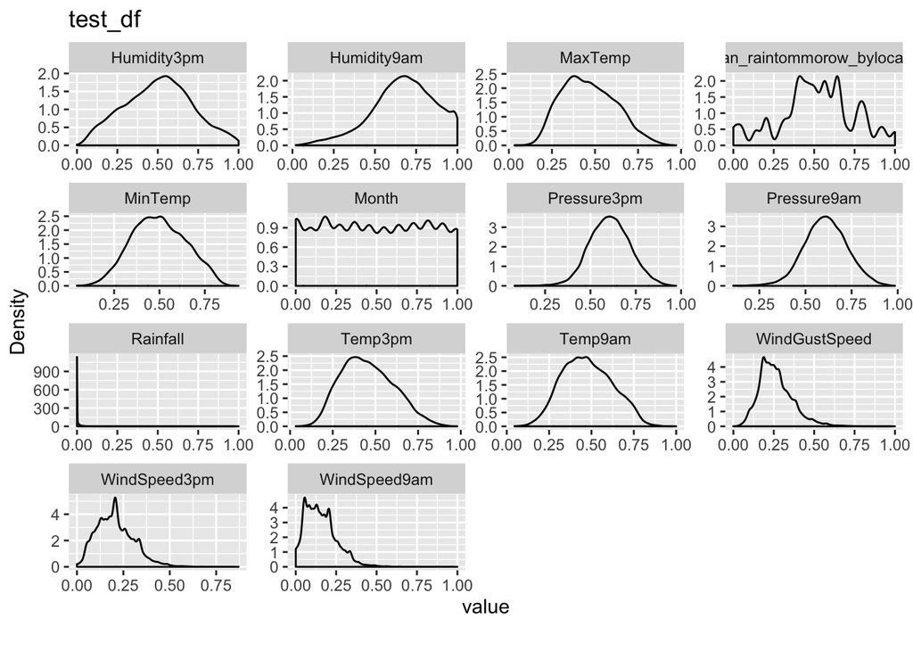

```r
target <- as.numeric( dirty_df$RainTomorrow) -1



##### training and test data 4:1

n <-  length(clean_df[,1])

random_ind <- sample( 1:n)

test_ind <- random_ind[ 1:round(n/5)]

train_ind <- random_ind[ (round(n/5)+1):n]



test_df <- clean_df[test_ind,]

test_lab <- target[test_ind]



train_df <- clean_df[train_ind,]

train_lab <- target[train_ind]



#mostly the same distribution: quantitive

DataExplorer::plot_density(test_df, title = "test_df")
```

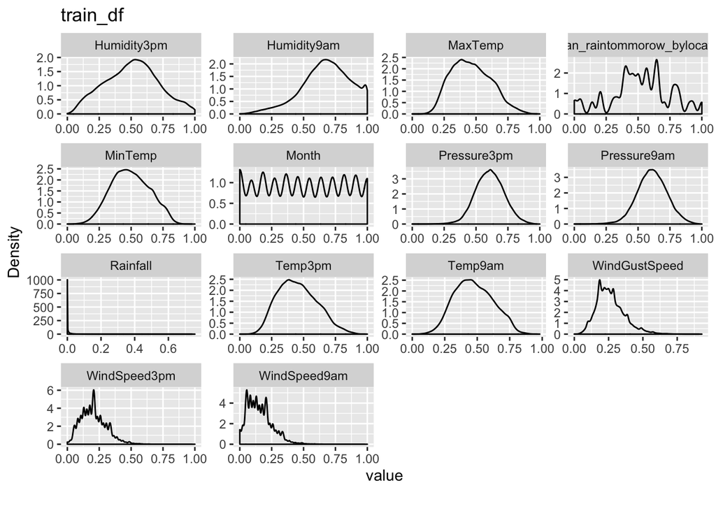

```r
DataExplorer::plot_density(train_df, title = "train_df")
```

```r
#mostly the same distribution: categorical

n_test <- length( test_lab)

n_train <- length( train_lab)

RainToday_percentage <- c( sum( test_df$RainToday) / n_test,

                sum( train_df$RainToday ) / n_train)

Labels_percentage <- c( sum( test_lab) / n_test,

                sum( train_lab ) / n_train)

data.frame( RainToday_percentage, Labels_percentage, row.names = c("test","train"))
```

```
##       RainToday_percentage Labels_percentage
## test             0.2229799         0.2208545
## train            0.2250720         0.2217290
```

## Measures

*Carnet* has functions for precision, recall and F1. Custom *accuracy* function were created. All function get confusion matrix as parameter. Also it was calculated accuracy of model, which always says that it won’t rain next day. It is comparison for other models.

```r
library(caret)
#precision(conf, relevant = "1")

#recall( conf, relevant = "1")

#F_meas( conf, relevant = "1")



accuracy <- function(conf){

  sum( diag(conf)) / sum( conf)

}



#what if model suggested that it always will be sun next day

Accuracy_of_dum_model <- sum( 1 - test_lab) / length( test_lab)

Accuracy_of_dum_model
```

```
## [1] 0.7791455
```

## Models

Three models were used: decision tree, k nearest neighbours and naive bayens.

Decision tree, from package *rpart*, is set with parameter cp = 0.01, with this parameter set to 0.05 it’s reduced to one question about humidity at 3 pm. Only firts is shown.

Naive bayens, from package *mlr*, was tested with *laplace* parameter set to different values, in theory it should smother the probability but even for very big numbers model behaved in the same way. m

Measures for laplace = 0 are shown.

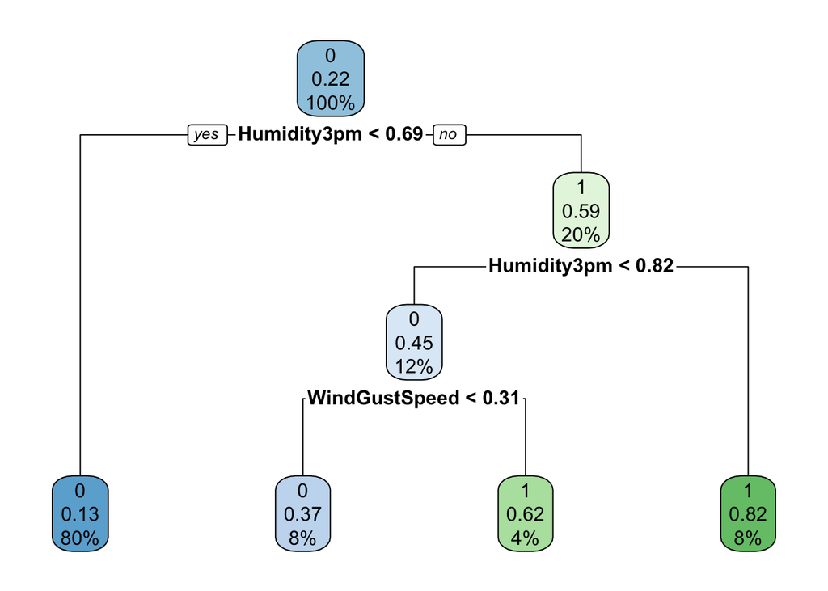

```r
##### tree

library( rpart)



train_lab_df_tree <- cbind( train_df, train_lab)



#tree <- rpart( train_lab~., train_lab_df_tree, method = "class",

#               control = rpart.control(cp = 0.05))

#pred_tree <- predict( tree, test_df, method ='class')[,2]

#conf_tree <- table( if_else( pred_tree > 0.5, 1, 0), test_lab)





tree <- rpart( train_lab~., train_lab_df_tree, method = "class",

               control = rpart.control(cp = 0.01))

pred_tree <- predict( tree, test_df, method ='class')[,2]

conf_tree <- table( if_else( pred_tree > 0.5, 1, 0), test_lab)



rpart.plot::rpart.plot( tree)
```

```r
#measures

acc_tree <- accuracy( conf_tree)

prec_tree <- precision(conf_tree, relevant = "1")

rec_tree <- recall( conf_tree, relevant = "1")

f1_tree <- F_meas( conf_tree, relevant = "1")









##### knn

library(class)

#num <- 5

#accs_knn <- rep(0,num)

#confs_knn <- list()

#for (k in 1:num){

#  knn1 <- knn( train_df, test_df, train_lab, k=k)

#  conf <- table(knn1, test_lab)

#  confs_knn[[k]] <- conf

#  accs_knn[k] <- accuracy( conf)

#}



knn <- knn( train_df, test_df, train_lab, k=9)

conf_knn <- table(knn, test_lab)



#measures

acc_knn <- accuracy( conf_knn)

prec_knn <- precision(conf_knn, relevant = "1")

rec_knn <- recall( conf_knn, relevant = "1")

f1_knn <- F_meas( conf_knn, relevant = "1")











##### Naive Bayens

library(mlr)
train_lab_df_NB <- cbind( train_df, factor( train_lab))

names( train_lab_df_NB) <- c( names(train_df), "train_lab")



#ls_i <- c(0,1,2,4,8,16,32,64)

#accs_nb <- rep(0, length(ls_i))

#confs_nb <- list()

#task <- makeClassifTask( data = train_lab_df_NB, target = "train_lab")

#for (i in 1:length(ls_i)) {

#  select_model <- makeLearner("classif.naiveBayes", laplace =ln_i)

#  NB_mlr = train(select_model, task)

#  pred_nb <- as.data.frame( predict( NB_mlr, newdata = test_df))[,1]

#  conf_nb <- table( pred_nb, test_lab)

#  confs_nb[[i]] <- conf_nb

#  accs_nb[i] <- accuracy( conf_nb)

#}



task <- makeClassifTask( data = train_lab_df_NB, target = "train_lab")

select_model <- makeLearner("classif.naiveBayes", laplace =0)

NB_mlr = train(select_model, task)

pred_nb <- as.data.frame( predict( NB_mlr, newdata = test_df))[,1]

conf_nb <- table( pred_nb, test_lab)



#measures

acc_nb <- accuracy( conf_nb)

prec_nb <- precision(conf_nb, relevant = "1")

rec_nb <- recall( conf_nb, relevant = "1")

f1_nb <- F_meas( conf_nb, relevant = "1")









#summary

Accuracy <- c( acc_tree, acc_knn, acc_nb)

Precision <- c( prec_tree, prec_knn, prec_nb)

Recall <- c( rec_tree, prec_knn, prec_nb)

F1_score <- c( f1_tree, f1_knn, f1_nb)



data.frame( Accuracy, Precision, Recall, F1_score, row.names = c("Tree","k-nearest","Naive_Bayens"))
```

```
##               Accuracy Precision    Recall  F1_score
## Tree         0.8368386 0.7559921 0.3857257 0.5108191
## k-nearest    0.8532654 0.7483680 0.7483680 0.6034937
## Naive_Bayens 0.8130175 0.5812620 0.5812620 0.5644146
```

```r
Accuracy_of_dum_model
```

```
## [1] 0.7791455
```

## Summary of models and discussion

K nearest neighbours was the best model overall.

Naive bayens was the worst of the three. Maybe because categories aren’t very correlated and naive assumption that categories aren’t independent from encoded, wich in weather prediction isn’t good assumption.

Overall accuracy of models haven’t increased significantly from dum model. But accuracy isn’t good measurement for this data because there is high proportion of days without rain. Also weather prediction is hard because there are many crucial elements ( some not in data like cloud coverage) to work with and making prediction only on data from one day and location isn’t enough.

Future models could be trained for every location separately, for example random forest, or by climate in that region, but more data would be needed. Location is maybe crucial as the north and the south have raining season are in the different parts of the year.